# Reproducible Resarch - Assignment Activity Monitoring

The dataset is stored in a comma-separated-value (CSV) file and there are a total of 17,568 observations in this dataset.

## Requirements:

1. Code for reading in the dataset and/or processing the data
2. Histogram of the total number of steps taken each day
3. Mean and median number of steps taken each day
4. Time series plot of the average number of steps taken
5. The 5-minute interval that, on average, contains the maximum number of steps
6. Code to describe and show a strategy for imputing missing data
7. Histogram of the total number of steps taken each day after missing values are imputed
8. Panel plot comparing the average number of steps taken per 5-minute interval across weekdays and weekends
9. All of the R code needed to reproduce the results (numbers, plots, etc.) in the report

### 1. Code for reading in the dataset and/or processing the data

```r
setwd("C:\\Users\\tkondi\\Desktop\\DataScientist\\ReproducibleResearch")
activity.monitoring <-  read.table("activity.csv",sep=",",header = TRUE)
```

### 2. Histogram of the total number of steps taken each day

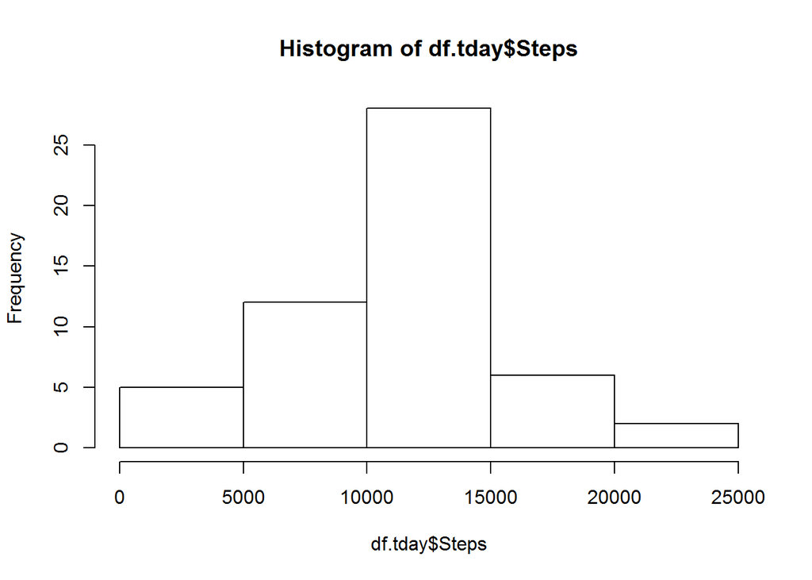

```r
tday <- tapply(activity.monitoring$steps,activity.monitoring$date,sum)
df.tday <- data.frame(Date=names(tday),Steps=tday)
stepsByDate <- aggregate(activity.monitoring$steps,list(activity.monitoring$date),sum)
names(stepsByDate) <- c("Date","Steps")
hist(df.tday$Steps)
```

### 3. What is mean total number of steps taken per day

```r
mean <- mean(stepsByDate$Steps,na.rm = TRUE)
median <- median(stepsByDate$Steps, na.rm = TRUE)
paste("Mean:",round(mean,2),"-","Median:",median,sep=" ")
```

```
## [1] "Mean: 10766.19 - Median: 10765"
```

### 4. Time series plot of the average number of steps taken

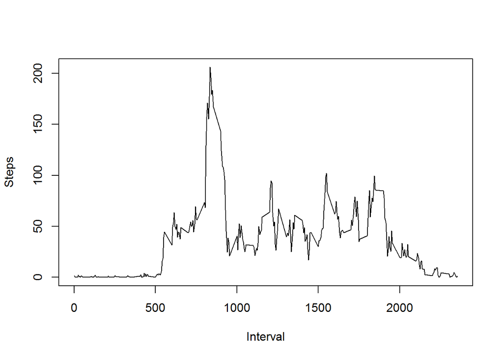

```r
meanStepsByInterval <-  aggregate(activity.monitoring$steps,list(activity.monitoring$interval),mean,na.rm = TRUE)
names(meanStepsByInterval) <- c("Interval", "Steps")
with(meanStepsByInterval, plot(Interval,Steps,type="l"))
```

```r
#ggplot(activity.monitoring, aes(x=interval, y=steps), na.rm = TRUE )  + stat_summary(fun.y="mean",,geom="bar")
```

### 5. The 5-minute interval that, on average, contains the maximum number of steps

```r
meanStepsByInterval[meanStepsByInterval$Steps==max(meanStepsByInterval$Steps),]
```

```
##     Interval    Steps
## 104      835 206.1698
```

### 6. Code to describe and show a strategy for imputing missing data

```r
paste("Missing values are",nrow(activity.monitoring[is.na(activity.monitoring$steps),]),"of",nrow(activity.monitoring),"total rows.", round(nrow(activity.monitoring[is.na(activity.monitoring$steps),])/nrow(activity.monitoring)*100,2),"%",sep=" ")
```

```
## [1] "Missing values are 2304 of 17568 total rows. 13.11 %"
```

#### Devise a strategy for filling in all of the missing values in the dataset. The strategy does not need to be sophisticated. For example, you could use the mean/median for that day, or the mean for that 5-minute interval, etc.

For the porpuse of the assignment for missing value will use the means of the intervals as using means of interval the intevals means are preserved. For better imputation I’ve found that multiple imputation techincs can be used as described in following article:https://www.analyticsvidhya.com/blog/2016/03/tutorial-powerful-packages-imputing-missing-values/

```r
#code for mearging each interval with corresponding mean value
intervalByMean <- merge(activity.monitoring,meanStepsByInterval, by.x = "interval", by.y = "Interval" )
```

#### Create a new dataset that is equal to the original dataset but with the missing data filled in.

```r
dsNoNAs <- activity.monitoring
#assigning mean step to each step
dsNoNAs$steps[is.na(dsNoNAs$steps)]<-intervalByMean$Steps[is.na(intervalByMean$steps)]
```

### 7. Histogram of the total number of steps taken each day after missing values are imputed

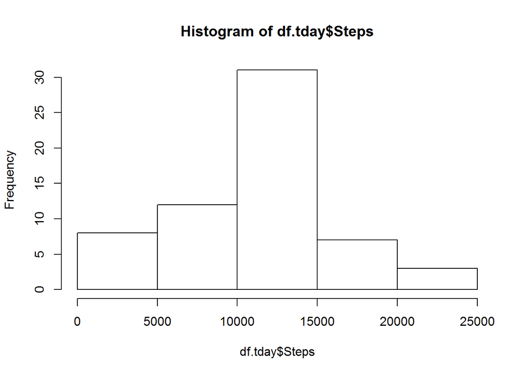

```r
tday <- tapply(dsNoNAs$steps,dsNoNAs$date,sum)
df.tday <- data.frame(Date=names(tday),Steps=tday)
stepsByDate <- aggregate(dsNoNAs$steps,list(dsNoNAs$date),sum)
names(stepsByDate) <- c("Date","Steps")
hist(df.tday$Steps)
```

Do these values differ from the estimates from the first part of the assignment? What is the impact of imputing missing data on the estimates of the total daily number of steps?

```r
mean <- mean(stepsByDate$Steps,na.rm = TRUE)
median <- median(stepsByDate$Steps, na.rm = TRUE)
paste("Mean:",round(mean,2),"-","Median:",median,sep=" ")
```

```
## [1] "Mean: 10766.19 - Median: 11015"
```

From before results the mean as expected dosen’t change as the mean of steps has been used but changes the meadina of population

### 8. Panel plot comparing the average number of steps taken per 5-minute interval across weekdays and weekends

#### Create a new factor variable in the dataset with two levels - “weekday” and “weekend” indicating whether a given date is a weekday or weekend day.

```r
dsNoNAs[,"weekday"] <-ifelse(
                    weekdays(as.Date(dsNoNAs$date))=="domenica" |
                    weekdays(as.Date(dsNoNAs$date)) == "sabato",
                    "weekend","weekday"
                      )
```

#### Make a panel plot containing a time series plot (i.e. type = “l”) of the 5-minute interval (x-axis) and the average number of steps taken, averaged across all weekday days or weekend days (y-axis). See the README file in the GitHub repository to see an example of what this plot should look like using simulated data.

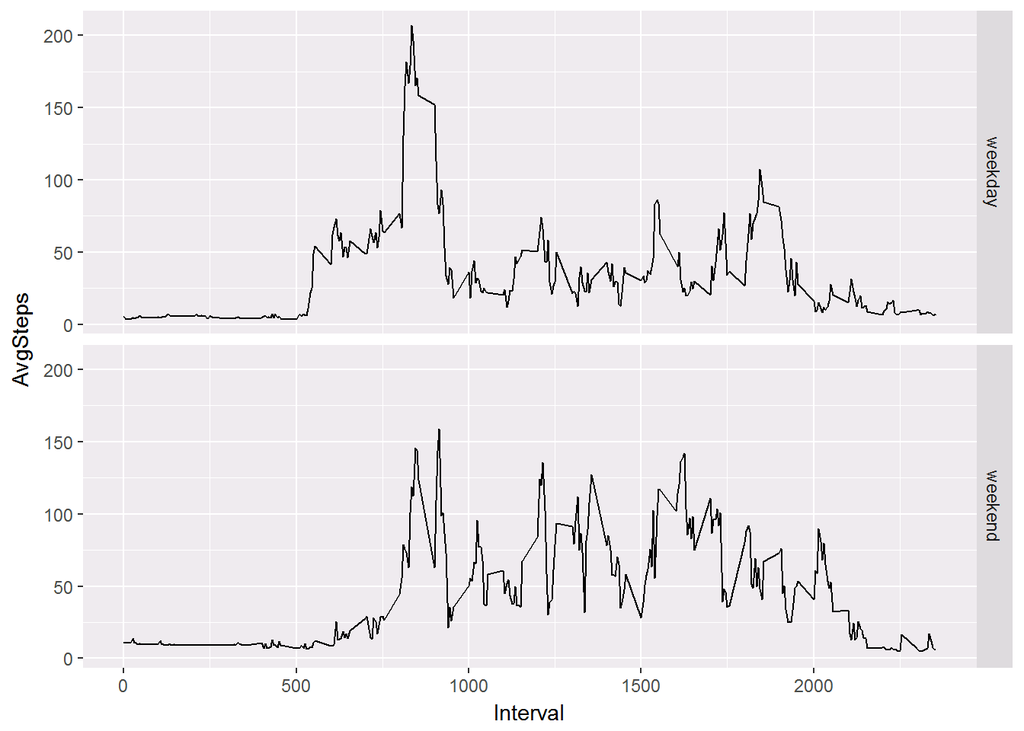

```r
  avgStepsByDate <- aggregate(dsNoNAs$steps,list(dsNoNAs$interval,dsNoNAs$weekday),mean)
  names(avgStepsByDate) <- c("Interval","Weekday","AvgSteps")
  library(ggplot2)
  ggplot(avgStepsByDate,aes(Interval,AvgSteps)) + facet_grid(factor(Weekday)~. ) +   geom_line()
```

### 9. All of the R code needed to reproduce the results (numbers, plots, etc.) in the report

All has been provided.